# NMA for Dichotomous Outcomes

Justin Slater, Audrey Beliveau

2020-11-25

### Data Preparation

```r
library(BUGSnet)
data(thrombolytic)
age <- rnorm(nrow(thrombolytic), 60, 10)
dich.slr <- data.prep(arm.data = cbind(thrombolytic, age),
                     varname.t = "treatment",
                     varname.s = "study")
```

## Feasibility Assessment

### Network Plot

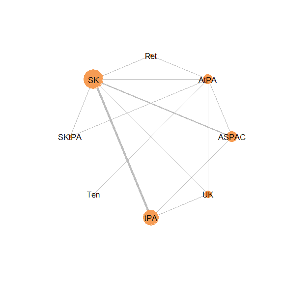

```r
 net.plot(dich.slr, node.scale = 1.5, edge.scale=0.5)
```

### Generate Network Characteristics via `net.tab()`

```r
network.char <- net.tab(data = dich.slr,
                        outcome = "events",
                        N = "sampleSize",
                        type.outcome = "binomial",
                        time = NULL)
```

#### Network Characteristics

`network.char$network` generates characteristics about the network, such as connectedness, number of treatments in the network, and in the case of a binomial outcome, the number of events in the network.

| Characteristic | Value |
| --- | --- |
| Number of Interventions | 8 |
| Number of Studies | 28 |
| Total Number of Patients in Network | 146528 |
| Total Possible Pairwise Comparisons | 28 |
| Total Number of Pairwise Comparisons With Direct Data | 13 |
| Is the network connected? | TRUE |
| Number of Two-arm Studies | 26 |
| Number of Multi-Arms Studies | 2 |
| Total Number of Events in Network | 12009 |
| Number of Studies With No Zero Events | 28 |
| Number of Studies With At Least One Zero Event | 0 |
| Number of Studies with All Zero Events | 0 |

#### Intervention Characteristics

`network.char$intervention` generates outcome and sample size data broken down by treatment.

| treatment | n.studies | n.events | n.patients | min.outcome | max.outcome | av.outcome |
| --- | --- | --- | --- | --- | --- | --- |
| ASPAC | 9 | 1514 | 14769 | 0.0344828 | 0.1051332 | 0.1025120 |
| AtPA | 8 | 1565 | 24550 | 0.0217391 | 0.0838710 | 0.0637475 |
| Ret | 3 | 1034 | 13301 | 0.0414201 | 0.0901804 | 0.0777385 |
| SK | 16 | 4181 | 48650 | 0.0348837 | 0.1055878 | 0.0859404 |
| SKtPA | 2 | 729 | 10437 | 0.0550459 | 0.0700039 | 0.0698477 |
| Ten | 1 | 523 | 8461 | 0.0618130 | 0.0618130 | 0.0618130 |
| tPA | 13 | 2418 | 25405 | 0.0338983 | 0.1031573 | 0.0951781 |
| UK | 6 | 45 | 955 | 0.0353535 | 0.1296296 | 0.0471204 |

#### Comparison Characteristics

`network.char$comparison` generates outcome and sample size data broken down by treatment **comparison**.

| comparison | n.studies | n.patients | n.outcomes | proportion |
| --- | --- | --- | --- | --- |
| ASPAC vs. AtPA | 2 | 706 | 38 | 0.0538244 |
| ASPAC vs. SK | 5 | 28324 | 2946 | 0.1040107 |
| ASPAC vs. tPA | 3 | 28027 | 2901 | 0.1035073 |
| AtPA vs. Ret | 2 | 15383 | 1133 | 0.0736527 |
| AtPA vs. SK | 1 | 30507 | 2124 | 0.0696234 |
| AtPA vs. SKtPA | 1 | 20672 | 1375 | 0.0665151 |
| AtPA vs. Ten | 1 | 16949 | 1045 | 0.0616556 |
| AtPA vs. UK | 2 | 698 | 37 | 0.0530086 |
| Ret vs. SK | 1 | 5986 | 555 | 0.0927163 |
| SK vs. SKtPA | 2 | 30707 | 2205 | 0.0718077 |
| SK vs. tPA | 8 | 49529 | 4762 | 0.0961457 |
| SK vs. UK | 1 | 401 | 17 | 0.0423940 |
| tPA vs. UK | 3 | 773 | 39 | 0.0504528 |

## Main analysis

`nma.model()` creates BUGS code and that will be put into `nma.run()` and analysed through JAGS (Plummer 2017). The `reference` parameter indicates the name of the treatment that will be seen as the ‘referent’ comparator, this is often a placebo of some sort. In our case, it is streptokinase (“SK”). Since our outcome is dichotomous, and we are not interested in event rates, we are using the “binomial” family. In our case, we want to compare relative risks, so we are using the $log$ link. If you are interested in using an odds ratio, set `link="logit"`.

```r
fixed_effects_model <- nma.model(data=dich.slr,
                     outcome="events",
                     N="sampleSize",
                     reference="SK",
                     family="binomial",
                     link="log",
                     effects="fixed")

random_effects_model <- nma.model(data=dich.slr,
                     outcome="events",
                     N="sampleSize",
                     reference="SK",
                     family="binomial",
                     link="log",
                     effects="random")
```

If you want to review or modify the BUGS code, you can review it by outputting `cat(fixed_effects_model$bugs)` and `cat(random_effects_model$bugs)`.

The next step is to run the NMA model using `nma.run()`. Since we are working in a Bayesian framework, we need to specify the number of adaptations, burn-ins, and iterations. A description of Bayesian MCMC is omitted here, we direct the reader to any introductory text on Bayesian Modelling (Lunn et al. 2012).

```r
set.seed(20190829)
fixed_effects_results <- nma.run(fixed_effects_model,
                           n.adapt=1000,
                           n.burnin=1000,
                           n.iter=10000)

random_effects_results <- nma.run(random_effects_model,
                           n.adapt=1000,
                           n.burnin=1000,
                           n.iter=10000)
```

# Assess model fit

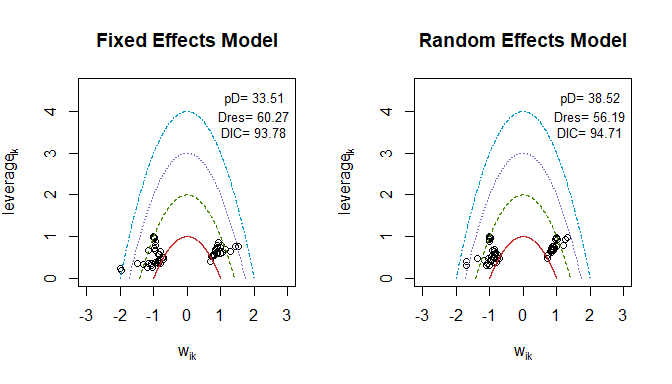

```r
par(mfrow = c(1,2))
nma.fit(fixed_effects_results, main = "Fixed Effects Model" )
nma.fit(random_effects_results, main= "Random Effects Model")
```

## Results

### Sucra Plot

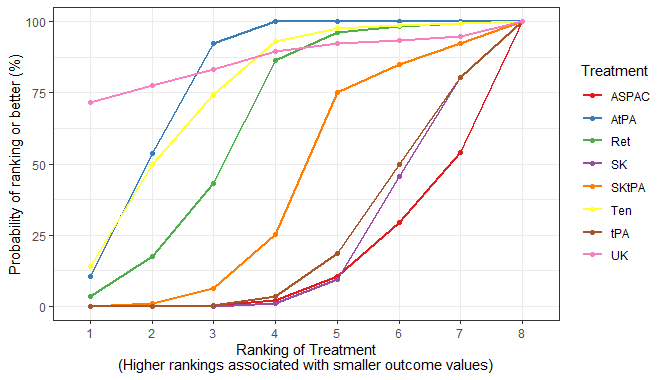

```r
sucra.out <- nma.rank(fixed_effects_results, largerbetter=FALSE, sucra.palette= "Set1")
sucra.out$sucraplot
```

### League Heat Plot

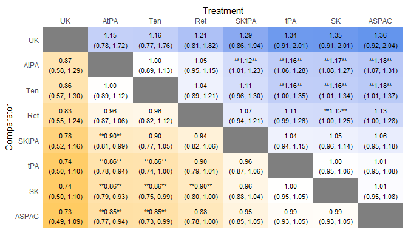

```r
league.out <- nma.league(fixed_effects_results,
                         central.tdcy="median",
                         order = sucra.out$order)
league.out$heatplot
```

### Forest Plot

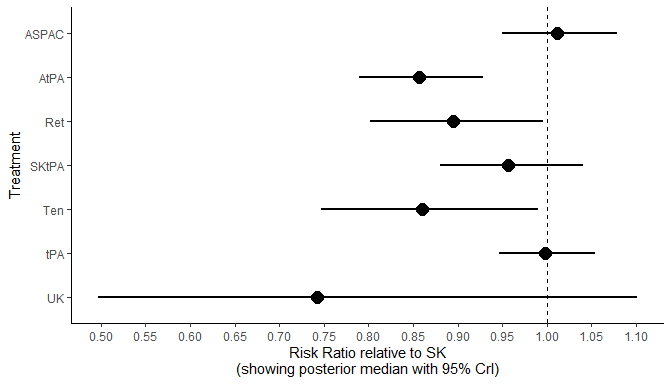

```r
nma.forest(fixed_effects_results,
           central.tdcy="median",
           comparator = "SK")
```

## Check inconsistency

```r
fe_inconsistency_model <- nma.model(data=dich.slr,
                     outcome="events",
                     N="sampleSize",
                     reference="SK",
                     family="binomial",
                     link="log",
                     type = "inconsistency",
                     effects="fixed")

fe_inconsistency_results <- nma.run(fe_inconsistency_model,
                           n.adapt=1000,
                           n.burnin=1000,
                           n.iter=10000)
```

```r
par(mfrow = c(1,2))
fe_model_fit <- nma.fit(fixed_effects_results)
inconsist_model_fit <- nma.fit(fe_inconsistency_results)
```

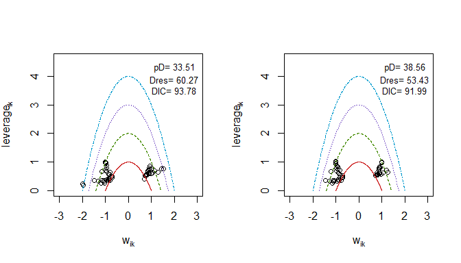

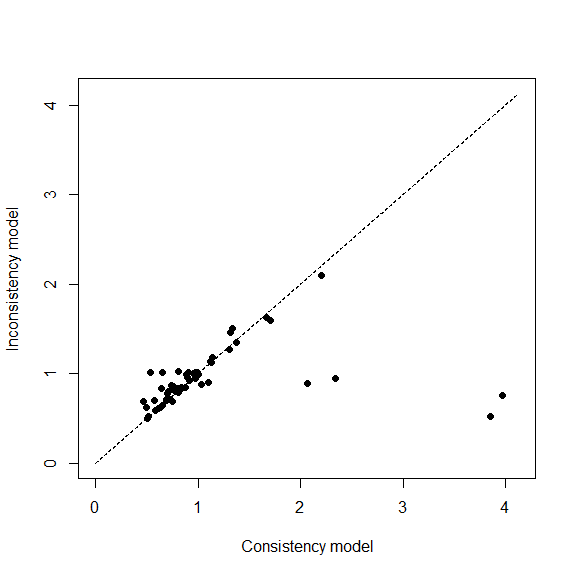

```r
nma.compare(fe_model_fit, inconsist_model_fit)
```

# References

Lunn, David, Chris Jackson, Nicky Best, David Spiegelhalter, and Andrew Thomas. 2012. *The Bugs Book: A Practical Introduction to Bayesian Analysis*. Chapman; Hall/CRC.

Plummer, Martyn. 2017. *JAGS Version 4.3.0 User Manual*. http://people.stat.sc.edu/hansont/stat740/jags_user_manual.pdf.